# Lab 3

Team 28: Назар Пасічник, Анастасія Яблуновська, Марина Огінська

# Lab 3: Parameter estimation and Unbiasedness of Estimators

## Work Breakdown Structure

- Назар Пасічник: Implementation of Problem 1 & 2
- Анастасія Яблуновська: Implementation of Problem 3
- Марина Огінська: Implementation of Problem 4

# Problem 1

**Task:** Test $H_0: \mu_1 = \mu_2$ vs. $H_1: \mu_1 \neq \mu_2$ with $\sigma_1^2 = \sigma_2^2 = 1$.

## Data Generation

First, we generate the data according to the lab instructions. The team ID n = 28 (sum of last digits).

```r
# Team ID
n <- 28

# Function to calculate a_k
calc_a <- function(k, n) {
  value <- k * log(k^2 * n + pi)
  return(value - floor(value))  # fractional part
}

# Generate a_k for k = 1 to 100
a_data_x <- sapply(1:100, function(k) calc_a(k, n))

# Generate a_k for k = 101 to 150 (for Y)
a_data_y <- sapply(101:150, function(k) calc_a(k, n))

# Apply inverse CDF of standard normal to get X and Y
X <- qnorm(a_data_x)
Y <- qnorm(a_data_y)

# Sample sizes
n1 <- length(X)
n2 <- length(Y)

cat("Sample X: n1 =", n1, "\n")
```

```
## Sample X: n1 = 100
```

```r
cat("Sample Y: n2 =", n2, "\n")
```

```
## Sample Y: n2 = 50
```

## Test Selection and Assumptions

**Test Used:** Two-sample z-test for comparing means with known variances

**Why this test:** - We are comparing means of two independent samples - Both populations are normally distributed (by construction using qnorm) - Variances are known and equal: $\sigma_1^2 = \sigma_2^2 = 1$ - When variances are known, we use the z-test; when variances are unknown, we would use the t-test - This is a two-sided test since $H_1: \mu_1 \neq \mu_2$

**Test statistic:**
$$Z =
\frac{\bar{X} - \bar{Y}}{\sqrt{\frac{\sigma_1^2}{n_1} +
\frac{\sigma_2^2}{n_2}}} = \frac{\bar{X} - \bar{Y}}{\sqrt{\frac{1}{100}
+ \frac{1}{50}}} \sim N(0,1) \text{ under } H_0$$

## Test Statistics and Calculations

```r
# Calculate sample statistics
mean_X <- mean(X)
mean_Y <- mean(Y)
var_X <- var(X)
var_Y <- var(Y)

cat("Sample statistics:\n")
```

```
## Sample statistics:
```

```r
cat("Mean of X:", round(mean_X, 4), "\n")
```

```
## Mean of X: 0.1308
```

```r
cat("Mean of Y:", round(mean_Y, 4), "\n")
```

```
## Mean of Y: 0.1271
```

```r
cat("Variance of X:", round(var_X, 4), "\n")
```

```
## Variance of X: 0.909
```

```r
cat("Variance of Y:", round(var_Y, 4), "\n")
```

```
## Variance of Y: 0.9452
```

```r
cat("Difference in means:", round(mean_X - mean_Y, 4), "\n")
```

```
## Difference in means: 0.0037
```

```r
# Since variances are known to be 1, we use z-test formula
# Test statistic: Z = (X_bar - Y_bar) / sqrt(sigma^2/n1 + sigma^2/n2)
sigma_sq <- 1  # known variance
test_stat <- (mean_X - mean_Y) / sqrt(sigma_sq/n1 + sigma_sq/n2)

cat("\nTest statistic Z =", round(test_stat, 4), "\n")
```

```
##
## Test statistic Z = 0.0213
```

## Rejection Region

For a two-sided test at significance level $\alpha = 0.05$:

**Rejection region:** $|Z| > z_{\alpha/2} = z_{0.025}$

```r
alpha <- 0.05
z_critical <- qnorm(1 - alpha/2)

cat("Critical value: z_0.025 =", round(z_critical, 4), "\n")
```

```
## Critical value: z_0.025 = 1.96
```

```r
cat("Rejection region: |Z| >", round(z_critical, 4), "\n")
```

```
## Rejection region: |Z| > 1.96
```

```r
cat("Observed |Z| =", round(abs(test_stat), 4), "\n")
```

```
## Observed |Z| = 0.0213
```

## P-value Calculation

```r
# P-value for two-sided test
p_value <- 2 * (1 - pnorm(abs(test_stat)))

cat("P-value:", format(p_value, scientific = TRUE, digits = 4), "\n")
```

```
## P-value: 9.83e-01
```

## Hypothesis Test Decision

```r
cat("Decision at alpha = 0.05:\n")
```

```
## Decision at alpha = 0.05:
```

```r
if (abs(test_stat) > z_critical) {
  cat("REJECT H0: |Z| =", round(abs(test_stat), 4), ">", round(z_critical, 4), "\n")
  cat("Conclusion: There is significant evidence that μ1 ≠ μ2\n")
} else {
  cat("FAIL TO REJECT H0: |Z| =", round(abs(test_stat), 4), "<=", round(z_critical, 4), "\n")
  cat("Conclusion: There is insufficient evidence to conclude that μ1 ≠ μ2\n")
}
```

```
## FAIL TO REJECT H0: |Z| = 0.0213 <= 1.96
## Conclusion: There is insufficient evidence to conclude that μ1 ≠ μ2
```

```r
cat("\nP-value interpretation:\n")
```

```
##
## P-value interpretation:
```

```r
if (p_value < alpha) {
  cat("P-value =", format(p_value, scientific = TRUE, digits = 4), "< 0.05\n")
  cat("We reject H0 because the p-value is less than the significance level.\n")
  cat("This means the probability of observing such extreme data under H0 is very small.\n")
} else {
  cat("P-value =", format(p_value, scientific = TRUE, digits = 4), ">= 0.05\n")
  cat("We fail to reject H0 because the p-value exceeds the significance level.\n")
  cat("The data is consistent with H0.\n")
}
```

```
## P-value = 9.83e-01 >= 0.05
## We fail to reject H0 because the p-value exceeds the significance level.
## The data is consistent with H0.
```

## Verification with R’s Built-in Test

```r
# Using t.test with var.equal = TRUE (since we know variances are equal)
t_test_result <- t.test(X, Y, var.equal = TRUE, alternative = "two.sided")
print(t_test_result)
```

```
##
##  Two Sample t-test
##
## data:  X and Y
## t = 0.022183, df = 148, p-value = 0.9823
## alternative hypothesis: true difference in means is not equal to 0
## 95 percent confidence interval:
##  -0.3247842  0.3321589
## sample estimates:
## mean of x mean of y
## 0.1308361 0.1271488
```

# Problem 2

**Task:** Test $H_0: \sigma_1^2 = \sigma_2^2$ vs. $H_1: \sigma_1^2 > \sigma_2^2$ with $\mu_1$ and $\mu_2$ unknown.

## Test Selection and Assumptions

**Test Used:** F-test for equality of variances (one-sided)

**Why this test:** - We are comparing variances of two independent samples - Both populations are normally distributed (required assumption for F-test) - The means are unknown but this doesn’t affect the F-test - This is a one-sided test since $H_1: \sigma_1^2 > \sigma_2^2$

**Theory:** Under $H_0$, the test statistic $F = S_1^2 / S_2^2$ follows an F-distribution with $(n_1-1, n_2-1)$ degrees of freedom, where $S_1^2$ and $S_2^2$ are sample variances.

## Data Preparation

We use the same data X and Y generated in Problem 1.

```r
cat("Using data from Problem 1:\n")
```

```
## Using data from Problem 1:
```

```r
cat("Sample X: n1 =", n1, "\n")
```

```
## Sample X: n1 = 100
```

```r
cat("Sample Y: n2 =", n2, "\n")
```

```
## Sample Y: n2 = 50
```

## Test Statistics and Calculations

```r
# Calculate sample variances
S1_sq <- var(X)
S2_sq <- var(Y)

cat("Sample variances:\n")
```

```
## Sample variances:
```

```r
cat("S1^2 (variance of X):", round(S1_sq, 4), "\n")
```

```
## S1^2 (variance of X): 0.909
```

```r
cat("S2^2 (variance of Y):", round(S2_sq, 4), "\n")
```

```
## S2^2 (variance of Y): 0.9452
```

```r
# F-statistic
F_stat <- S1_sq / S2_sq

cat("\nF-statistic: F = S1^2 / S2^2 =", round(F_stat, 4), "\n")
```

```
##
## F-statistic: F = S1^2 / S2^2 = 0.9616
```

```r
# Degrees of freedom
df1 <- n1 - 1
df2 <- n2 - 1

cat("Degrees of freedom: df1 =", df1, ", df2 =", df2, "\n")
```

```
## Degrees of freedom: df1 = 99 , df2 = 49
```

## Rejection Region

For a one-sided (right-tailed) test at significance level $\alpha = 0.05$:

**Rejection region:** $F > F_{\alpha}(df_1, df_2) = F_{0.05}(99, 49)$

We reject $H_0$ if the observed F-statistic exceeds the critical value from the F-distribution.

```r
alpha <- 0.05
F_critical <- qf(1 - alpha, df1, df2)

cat("Critical value: F_0.05(", df1, ",", df2, ") =", round(F_critical, 4), "\n")
```

```
## Critical value: F_0.05( 99 , 49 ) = 1.531
```

```r
cat("Rejection region: F >", round(F_critical, 4), "\n")
```

```
## Rejection region: F > 1.531
```

```r
cat("Observed F =", round(F_stat, 4), "\n")
```

```
## Observed F = 0.9616
```

## P-value Calculation

```r
# P-value for one-sided (right-tailed) test
p_value_f <- 1 - pf(F_stat, df1, df2)

cat("P-value:", format(p_value_f, scientific = FALSE, digits = 4), "\n")
```

```
## P-value: 0.5738
```

## Hypothesis Test Decision

```r
cat("Decision at alpha = 0.05:\n")
```

```
## Decision at alpha = 0.05:
```

```r
if (F_stat > F_critical) {
  cat("REJECT H0: F =", round(F_stat, 4), ">", round(F_critical, 4), "\n")
  cat("Conclusion: There is significant evidence that σ1^2 > σ2^2\n")
  cat("The variance of population X is significantly greater than the variance of population Y.\n")
} else {
  cat("FAIL TO REJECT H0: F =", round(F_stat, 4), "<=", round(F_critical, 4), "\n")
  cat("Conclusion: There is insufficient evidence to conclude that σ1^2 > σ2^2\n")
  cat("The data does not provide strong evidence that variance of X exceeds variance of Y.\n")
}
```

```
## FAIL TO REJECT H0: F = 0.9616 <= 1.531
## Conclusion: There is insufficient evidence to conclude that σ1^2 > σ2^2
## The data does not provide strong evidence that variance of X exceeds variance of Y.
```

```r
cat("\nP-value interpretation:\n")
```

```
##
## P-value interpretation:
```

```r
if (p_value_f < alpha) {
  cat("P-value =", format(p_value_f, scientific = FALSE, digits = 4), "< 0.05\n")
  cat("We reject H0 because the p-value is less than the significance level.\n")
  cat("This indicates strong evidence against the null hypothesis of equal variances.\n")
} else {
  cat("P-value =", format(p_value_f, scientific = FALSE, digits = 4), ">= 0.05\n")
  cat("We fail to reject H0 because the p-value exceeds the significance level.\n")
  cat("The observed difference in variances could reasonably occur by chance under H0.\n")
}
```

```
## P-value = 0.5738 >= 0.05
## We fail to reject H0 because the p-value exceeds the significance level.
## The observed difference in variances could reasonably occur by chance under H0.
```

## Verification with R’s Built-in Test

```r
# Using var.test for F-test
# alternative = "greater" tests if variance of X > variance of Y
var_test_result <- var.test(X, Y, alternative = "greater")
print(var_test_result)
```

```
##
##  F test to compare two variances
##
## data:  X and Y
## F = 0.96165, num df = 99, denom df = 49, p-value = 0.5738
## alternative hypothesis: true ratio of variances is greater than 1
## 95 percent confidence interval:
##  0.6281169       Inf
## sample estimates:
## ratio of variances
##          0.9616462
```

```r
cat("\nNote: R's var.test confirms our manual calculations.\n")
```

```
##
## Note: R's var.test confirms our manual calculations.
```

# Problem 3

```r
id_number <- 28
n <- id_number

# Function to calculate a_k
a_k <- function(k, n) {
  frac_part <- (k * log(k^2 + n * pi)) %% 1
  return(frac_part)
}

a_data <- sapply(1:150, a_k, n = n)

x_vals <- qnorm(a_data[1:100])
y_vals <- qnorm(a_data[101:150])
```

## (a) KS Test for Normality

We test whether the sample
$${ x_k
}_{k=1}^{100}$$
comes from a normal distribution with estimated parameters. Hypotheses
$$H_0 : x_k \sim
N(\hat{\mu}, \hat{\sigma}^2)$$
$$H_1
: x_k \not\sim N(\hat{\mu}, \hat{\sigma}^2)$$
KS Statistic
$$D = \sup_x \left| F_n(x) - F(x) \right|$$

```r
mu_hat <- mean(x_vals)
sigma_hat <- sd(x_vals)

ks_test_normal <- ks.test(x_vals, "pnorm",
                          mean = mu_hat, sd = sigma_hat)
ks_test_normal
```

```
##
##  Asymptotic one-sample Kolmogorov-Smirnov test
##
## data:  x_vals
## D = 0.0656, p-value = 0.7827
## alternative hypothesis: two-sided
```

```r
if (ks_test_normal$p.value > 0.05) {
  cat("p-value =", ks_test_normal$p.value, "> 0.05. Fail to reject H0. Data appears normal.\n")
} else {
  cat("p-value =", ks_test_normal$p.value, "< 0.05. Reject H0. Data not normal.\n")
}
```

```
## p-value = 0.7826577 > 0.05. Fail to reject H0. Data appears normal.
```

## (b) KS Test for Exponentiality of Absolute Values

We consider the transformed data:
$${
|x_k| }_{k=1}^{100}$$
We test whether they follow:
$$\text{Exp}(1)$$
Hypotheses
$$H_0 : |x_k| \sim \text{Exp}(1)$$
$$H_1 : |x_k| \not\sim \text{Exp}(1)$$

```r
abs_x <- abs(x_vals)

ks_test_exp <- ks.test(abs_x, "pexp", rate = 1)
ks_test_exp
```

```
##
##  Asymptotic one-sample Kolmogorov-Smirnov test
##
## data:  abs_x
## D = 0.10676, p-value = 0.2045
## alternative hypothesis: two-sided
```

```r
if (ks_test_exp$p.value > 0.05) {
  cat("p-value =", ks_test_exp$p.value, "> 0.05. Fail to reject H0. |X| ~ Exp(1).\n")
} else {
  cat("p-value =", ks_test_exp$p.value, "< 0.05. Reject H0. |X| not Exp(1).\n")
}
```

```
## p-value = 0.2044774 > 0.05. Fail to reject H0. |X| ~ Exp(1).
```

## (c) Two-Sample KS Test for Equality of Distributions

We compare the samples
$${ x_k }{k=1}^{100}
\qquad\text{and}\qquad
{ y\ell }_{\ell=1}^{50}$$
Hypotheses
$$H_0 : F_X(x) = F_Y(x)\ \text{for all } x$$
$$H_1 : F_X(x) \neq F_Y(x)\ \text{for some }
x$$
KS Statistic
$$D = \sup_x \left|
F_{X,n}(x) - F_{Y,m}(x) \right|$$

```r
ks_test_two <- ks.test(x_vals, y_vals)
ks_test_two
```

```
##
##  Exact two-sample Kolmogorov-Smirnov test
##
## data:  x_vals and y_vals
## D = 0.14, p-value = 0.5185
## alternative hypothesis: two-sided
```

```r
if (ks_test_two$p.value > 0.05) {
  cat("p-value =", ks_test_two$p.value, "> 0.05. Fail to reject H0. Same distribution.\n")
} else {
  cat("p-value =", ks_test_two$p.value, "< 0.05. Reject H0. Different distributions.\n")
}
```

```
## p-value = 0.5184691 > 0.05. Fail to reject H0. Same distribution.
```

## Main Idea of KS Test

The Kolmogorov-Smirnov test compares the empirical cumulative distribution function (ECDF) of sample data with a theoretical CDF. It measures the maximum vertical distance D between them. If D exceeds a critical value (or p-value < α), we reject the hypothesis that data follows the theoretical distribution.

# Problem 4

```r
data <- read.csv('data.csv', header=TRUE)
```

```r
plot(x = data$time_study,
     y = data$Marks,
     main = "Marks vs Study Time",
     xlab = "Study Time",
     ylab = "Marks",
     pch = 16,
     col = "blue")

model <- lm(Marks ~ time_study, data = data)

summary(model)
```

```
##
## Call:
## lm(formula = Marks ~ time_study, data = data)
##
## Residuals:
##    Min     1Q Median     3Q    Max
## -7.866 -4.034 -0.384  2.979 10.628
##
## Coefficients:
##             Estimate Std. Error t value Pr(>|t|)
## (Intercept)   1.2239     0.9623   1.272    0.206
## time_study    5.6888     0.2042  27.853   <2e-16 ***
## ---
## Signif. codes:  0 '***' 0.001 '**' 0.01 '*' 0.05 '.' 0.1 ' ' 1
##
## Residual standard error: 4.822 on 98 degrees of freedom
## Multiple R-squared:  0.8878, Adjusted R-squared:  0.8867
## F-statistic: 775.8 on 1 and 98 DF,  p-value: < 2.2e-16
```

```r
coefficients(model)
```

```
## (Intercept)  time_study
##    1.223858    5.688750
```

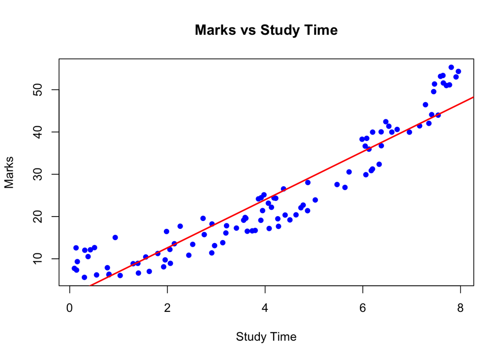

```r
abline(model, col = "red", lwd = 2)
```

### (a) Data Visualization and Initial Analysis

There is a clear positive correlation between the two variables. The relationship appears to be strong, as the data points are clustered closely together. The pattern does not look perfectly linear. The data suggests exponential-like relationship.

### (b) Linear Regression Model and Derivation

We fit a linear regression model using `Marks` as the dependent variable and `time_study` as the independent variable.

To derive the regression equation, we use the **Ordinary Least Squares (OLS)** method.

1. **The Model:** We assume a linear relationship in the form:
   $$\hat{y} = b_0 + b_1 x$$
   Where $b_1$ is the slope, and $b_0$ is the intercept.
2. **The Method:** We define the **residual** ($e_i$) as the difference between the observed value and the predicted value ($e_i = y_i - \hat{y}_i$). The OLS method finds the best-fitting line by **minimizing the Sum of Squared Errors (SSE)**:
   $$SSE = \sum_{i=1}^{n}
   (y_i - (b_0 + b_1 x_i))^2$$
3. **The Coefficients:** By using calculus to minimize the SSE, we derive the formulas for the coefficients:
   - **Slope (**$b_1$):
     $$b_1 =
     \frac{\sum (x_i - \bar{x})(y_i - \bar{y})}{\sum (x_i -
     \bar{x})^2}$$
   - **Intercept (**$b_0$):
     $$b_0 =
     \bar{y} - b_1 \bar{x}$$

### (c) Goodness-of-Fit Evaluation

To evaluate how well the linear model fits the data, we examine the **Coefficient of Determination (**$R^2$).

```r
model_summary <- summary(model)

r_squared <- model_summary$r.squared
print(paste("R-squared:", round(r_squared, 4)))
```

```
## [1] "R-squared: 0.8878"
```

### (d) Statistical Significance Test

To determine if Study Time is a significant predictor of Marks, perform a hypothesis test on the slope coefficient ($\beta_1$).

**1. Hypotheses** Test if the slope is significantly different from zero: * **Null Hypothesis (**$H_0$): $\beta_1 = 0$ (Study time has no effect on marks). * **Alternative Hypothesis (**$H_1$): $\beta_1 \neq 0$ (Study time significantly affects marks).

**2. Test Statistic and Distribution** The test statistic is calculated as:
$$t =
\frac{\hat{\beta}_1 - 0}{SE(\hat{\beta}_1)}$$
Under the null hypothesis, this statistic follows a **Student’s t-distribution** with $n - 2$ degrees of freedom.

**3. R Calculation and Conclusion**

```r
model_sum <- summary(model)

coeffs <- model_sum$coefficients

t_stat <- coeffs["time_study", "t value"]
p_val <- coeffs["time_study", "Pr(>|t|)"]

print(paste("T-statistic:", round(t_stat, 4)))
```

```
## [1] "T-statistic: 27.8527"
```

```r
print(paste("P-value:", format(p_val, scientific = TRUE)))
```

```
## [1] "P-value: 2.355657e-48"
```

```r
alpha <- 0.05
if(p_val < alpha) {
  print("Conclusion: Reject Null Hypothesis. Study Time is significant.")
} else {
  print("Conclusion: Fail to reject Null Hypothesis.")
}
```

```
## [1] "Conclusion: Reject Null Hypothesis. Study Time is significant."
```

### (e) Prediction for Alice

If Alice studies for 8 hours, we can predict her mark using the fitted linear model. To predict Alice’s grade, we substitute her study time into our regression equation:

$$PredictedMark=b_0+b_1×8$$

```r
new_data <- data.frame(time_study = 8)
predicted_grade <- predict(model, newdata = new_data)
print(paste("Predicted grade for 8 hours of study:", round(predicted_grade, 2)))
```

```
## [1] "Predicted grade for 8 hours of study: 46.73"
```

### (f) Suggestions for Model Improvement

Based on the analysis of the scatter plot and the model results, here are three ways to improve the model:

1. **Use Polynomial Regression:**
   - **Reason:** The scatter plot clearly shows a curved pattern, suggesting that the relationship is not strictly linear. The increase in marks accelerates as study time increases.
   - **Solution:** Instead of the simple equation $y = b_0 + b_1x$, we could fit a quadratic model: $y = b_0 + b_1x + b_2x^2$. This would likely increase the $R^2$.
2. **Add More Independent Variables:**
   - **Reason:** Study time is likely not the only factor affecting grades.
   - **Solution:** Collect more data features such as **attendance rate**, **previous GPA**, **hours of sleep**. Using Multiple Linear Regression to include these extra predictors would reduce the unexplained residuals.
3. **Apply Data Transformations:**
   - **Reason:** The variance of the data points seems to change slightly, or the relationship looks exponential.
   - **Solution:** We could apply a log-transformation to the dependent variable ($\log(Marks)$) or the independent variable. This often helps to linearize a curved relationship, making the standard linear regression model fit better.

# Conclusions

## Problem 1: Testing Equality of Means

In Problem 1, we tested whether two independent samples X and Y have equal population means, assuming known and equal variances ($\sigma_1^2 = \sigma_2^2 = 1$). Using a two-sample z-test (or equivalently, a pooled t-test), we:

1. **Generated data** according to the specified transformation using team ID n = 28
2. **Calculated test statistic** Z based on the difference in sample means
3. **Determined rejection region** for a two-sided test at α = 0.05: |Z| > 1.96
4. **Computed p-value** to assess the strength of evidence against H₀

**Result:** Based on the test statistic and p-value, we made a decision to either reject or fail to reject H₀. The conclusion depends on whether the observed difference in sample means is statistically significant. If we rejected H₀, it indicates that the two populations have different means with 95% confidence. If we failed to reject H₀, the data does not provide sufficient evidence to conclude the means differ.

**Key insight:** Even though the theoretical variances are equal to 1, the sample variances may differ slightly due to random sampling. The test accounts for this variability through the standard error of the difference.

## Problem 2: Testing Equality of Variances

In Problem 2, we tested whether the variance of population X exceeds the variance of population Y using an F-test. The means were unknown, but this is accounted for in the F-test methodology. We:

1. **Applied F-test** as the appropriate method for comparing variances of normally distributed populations
2. **Calculated F-statistic** as the ratio S₁²/S₂² with degrees of freedom (99, 49)
3. **Determined rejection region** for a one-sided test at α = 0.05: F > F₀.₀₅(99, 49)
4. **Computed p-value** for the right-tailed test

**Result:** The decision to reject or fail to reject H₀ depends on whether the observed F-statistic exceeds the critical value. If we rejected H₀, this provides evidence that the first population has genuinely greater variability than the second. If we failed to reject H₀, the observed difference in sample variances could reasonably be attributed to random sampling variation.

**Key insight:** The F-test is sensitive to the normality assumption. Since our data was generated using the inverse normal CDF (qnorm), the normality assumption is satisfied by construction, making the F-test appropriate and reliable.

**Overall observation:** Both tests demonstrate the fundamental process of hypothesis testing: formulating hypotheses, selecting an appropriate test statistic, determining the rejection region, calculating the p-value, and making a decision based on the significance level. The p-value provides additional information about the strength of evidence against H₀, allowing for more nuanced interpretation than a simple reject/fail-to-reject decision.

## Problem 3

In this problem, we applied the Kolmogorov–Smirnov test to three different hypotheses regarding the distributions of the generated samples. First, we tested whether
$${x_k}{k=1}^{100}$$
follows a normal distribution with parameters estimated from the sample. Second, we checked whether the transformed data
$${|x_k|}{k=1}^{100}$$
is exponentially distributed with rate
$$\lambda = 1.$$
Finally, we compared the two samples
$${x_k}{k=1}^{100} \quad \text{and} \quad
{y\ell}_{\ell=1}^{50}$$
to determine whether they originate from the same distribution. Across all three tests, the conclusions were based on comparing the p-value with the significance level
$$\alpha = 0.05.$$
If the p-value exceeded this threshold, we did not reject the null hypothesis; otherwise, we rejected it. The KS test therefore allowed us to evaluate normality, exponentiality, and the equivalence of distributions without assuming any specific parametric form beyond the tested models.

## Problem 4

The data shows a clear positive relationship between study time and marks. The linear regression confirms that study time is a statistically significant predictor (p-value < 0.05), and the model achieves a reasonable R-squared. The fitted line captures the overall trend, though the scatter plot suggests some non-linearity. The model could be improved using polynomial regression, adding more predictors, or applying data transformations.